# Practical Machine Learning Project Writeup

# Overview

The best machine learning algorithm I developed to predict activity quality from activity monitors was with random forest, as presented below. The OOB estimate of error rate was identified to be **2.18%**, so that is what I expected to see in my cross-validation predictions.

When I first attempted random forest, I applied the form “class ~ .” to the train() function to train against all 150+ variables, and I never waited long enough to see a result. I then produced series of graphs and looked for aesthetic, clean features with distinct variations during different regions of time. With a few selected variables, I was able to produce a fairly quick model with **8.87%** OOB estimate of error rate.

Considering which variables to add next, I noticed that all of the accel_* variables were similarly interesting looking and cheap to add to my training. After adding these to my list of predictor columns, I ended up with the **2.18%** error rate.

## Download, cache, and read data.

```r
getdata <- function(file, url) {
  if (! file.exists(file)) {
    paste("downloading", url, "into", file, "...")
    download.file(url, file, method="wget")
  }
  read.csv(file)
}
pmlData1 <- getdata("pml-training.csv",
                    "https://d396qusza40orc.cloudfront.net/predmachlearn/pml-training.csv")
pmlData2 <- getdata("pml-testing.csv",
                    "https://d396qusza40orc.cloudfront.net/predmachlearn/pml-testing.csv")
```

## Create data partitions for cross-validation

```r
inTrain <- createDataPartition(pmlData1$user_name, p=0.8, list=FALSE)
trainingData <- pmlData1[ inTrain, ]
testData     <- pmlData1[-inTrain, ]
```

## Determine predictors

```r
predictors <- c(
  'roll_belt'
  , 'gyros_belt_z'
  , 'roll_arm'
  , 'pitch_arm'
  , 'yaw_arm'
  , 'magnet_arm_z'
  , 'roll_dumbbell'
)

all_cols <- colnames(trainingData)
predictors <- c(predictors, all_cols[grep("^accel", all_cols)])
```

## Random Forest Model

```r
rf_model <- randomForest(trainingData[,predictors], trainingData$classe)
rf_model
```

```
##
## Call:
##  randomForest(x = trainingData[, predictors], y = trainingData$classe)
##                Type of random forest: classification
##                      Number of trees: 500
## No. of variables tried at each split: 4
##
##         OOB estimate of  error rate: 2.18%
## Confusion matrix:
##      A    B    C    D    E class.error
## A 4381   19   36   24    3  0.01837329
## B   36 2965   34    6    9  0.02786885
## C    8   43 2665   22    2  0.02737226
## D    5    1   61 2491    2  0.02695313
## E    1   11    8   11 2855  0.01074151
```

```r
importance(rf_model)
```

```
##                  MeanDecreaseGini
## roll_belt               1837.3854
## gyros_belt_z             587.1204
## roll_arm                 722.1479
## pitch_arm                512.0313
## yaw_arm                  470.5325
## magnet_arm_z             498.8325
## roll_dumbbell            816.0312
## accel_belt_x             375.2982
## accel_belt_y             265.6327
## accel_belt_z             774.8488
## accel_arm_x              689.6223
## accel_arm_y              412.4160
## accel_arm_z              389.6447
## accel_dumbbell_x         626.2124
## accel_dumbbell_y         789.1749
## accel_dumbbell_z         812.6655
## accel_forearm_x          725.1637
## accel_forearm_y          448.6591
## accel_forearm_z          657.4848
```

Confusion matrix applied to cross validation partition:

```r
confusionMatrix(predict(rf_model, testData[,predictors]), testData$classe)
```

```
## Confusion Matrix and Statistics
##
##           Reference
## Prediction    A    B    C    D    E
##          A 1101   17    3    4    0
##          B    4  722    9    1    3
##          C    8    7  668   17    1
##          D    4    1    2  634    1
##          E    0    0    0    0  716
##
## Overall Statistics
##
##                Accuracy : 0.9791
##                  95% CI : (0.9741, 0.9833)
##     No Information Rate : 0.2847
##     P-Value [Acc > NIR] : < 2.2e-16
##
##                   Kappa : 0.9736
##  Mcnemar's Test P-Value : NA
##
## Statistics by Class:
##
##                      Class: A Class: B Class: C Class: D Class: E
## Sensitivity            0.9857   0.9665   0.9795   0.9665   0.9931
## Specificity            0.9914   0.9946   0.9898   0.9976   1.0000
## Pos Pred Value         0.9787   0.9770   0.9529   0.9875   1.0000
## Neg Pred Value         0.9943   0.9921   0.9957   0.9933   0.9984
## Prevalence             0.2847   0.1904   0.1738   0.1672   0.1838
## Detection Rate         0.2807   0.1840   0.1703   0.1616   0.1825
## Detection Prevalence   0.2868   0.1884   0.1787   0.1637   0.1825
## Balanced Accuracy      0.9886   0.9806   0.9846   0.9820   0.9965
```

# Visualizations

These are the “interesting” variables which seemed pretty to me. First, I chose just a sampling of graphs which looked to have distinct regions of graph, and then I noticed that all of the accel_* graphs also seemed to have nice variability.

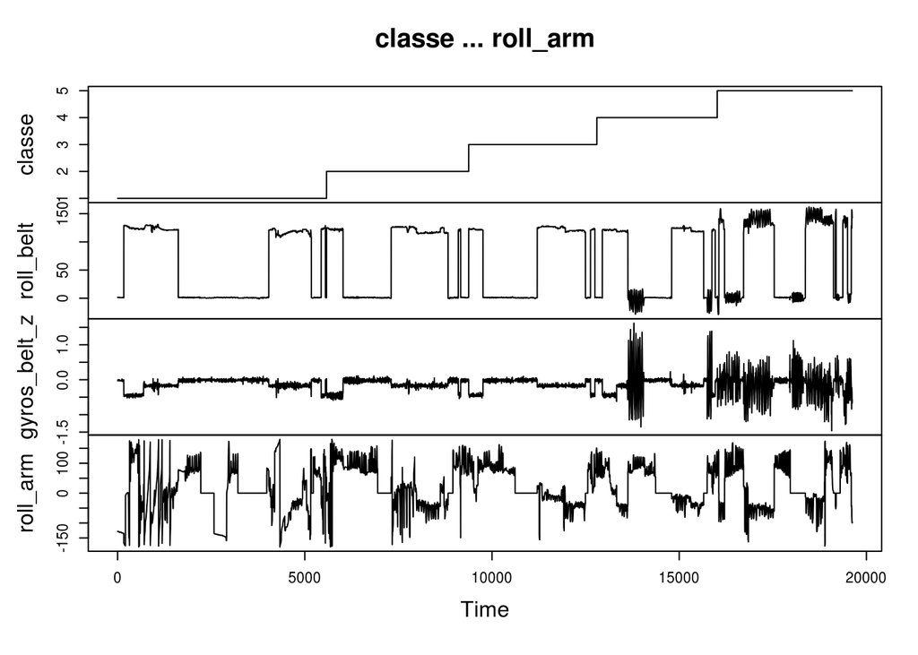

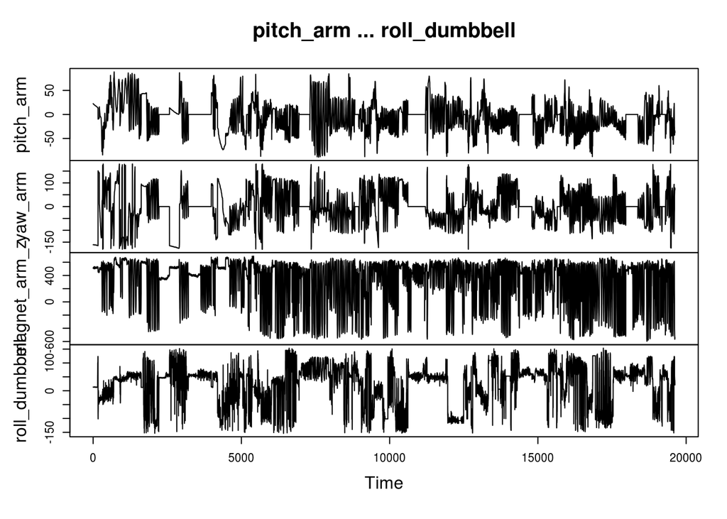

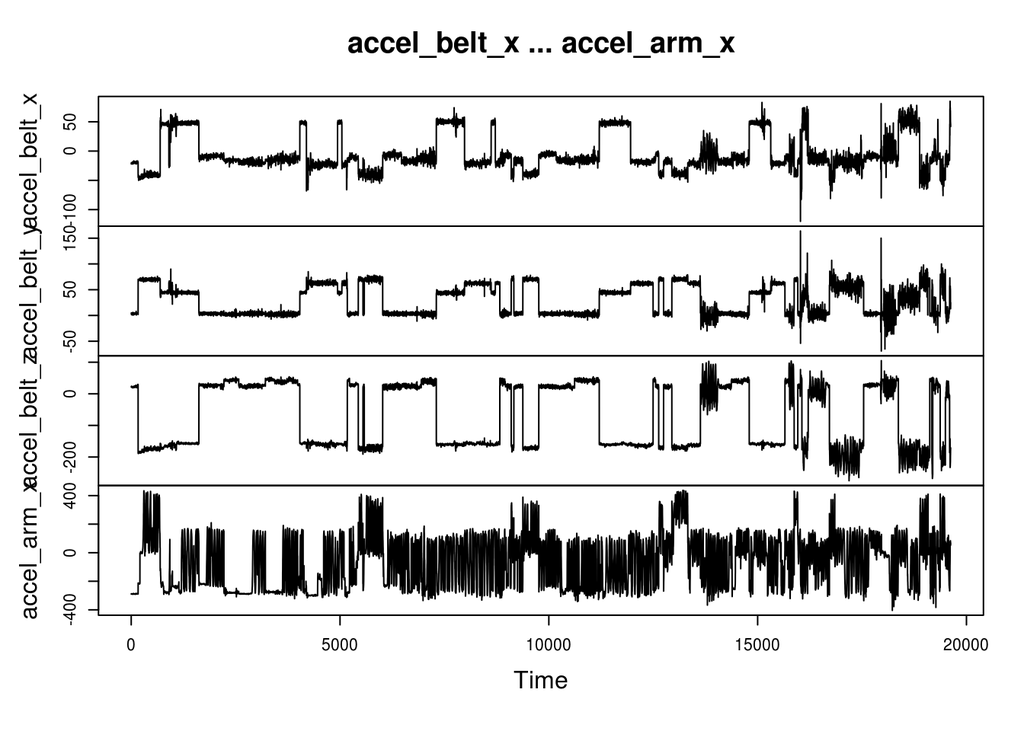

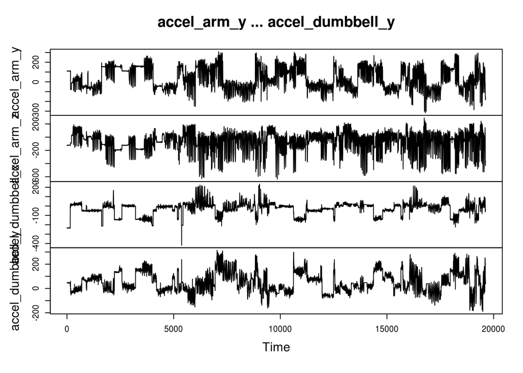

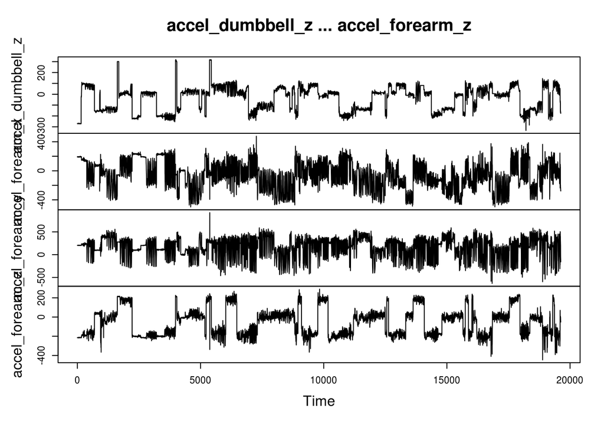

```r
plot_traces <- function(data, columns, step) {
  for (cur in seq(1,length(columns),step)) {
    first <- cur
    last <- min(cur+step-1, length(columns))
    plot.ts(data[,columns[first:last]], main=paste(columns[first],"...",columns[last]))
  }
}
plot_traces(pmlData1, c('classe', predictors), 4)
```

This code would display the remaining, “uninteresting”, boring variables which seemed either redundant or to have missing or unvarying data.

```r
all_data_cols <- colnames(pmlData1[,7:159])
uninteresting <- setdiff(all_data_cols, predictors)
#plot_traces(pmlData1, uninteresting, 8)
```

## Summarize people in the data.

```r
df <- pmlData1
people.names <- unique(df$user_name)
people <- data.frame(
  names=people.names,
  count=sapply(people.names, function(name) { nrow(df[df$user_name==name,]) }),
  min_t=sapply(people.names, function(name) {
    as.character(head(df[df$user_name==name,]$cvtd_timestamp,1)) }),
  max_t=sapply(people.names, function(name) {
    as.character(tail(df[df$user_name==name,]$cvtd_timestamp,1)) })
)
people
```

```
##      names count            min_t            max_t
## 1 carlitos  3112 05/12/2011 11:23 05/12/2011 11:25
## 2    pedro  2610 05/12/2011 14:22 05/12/2011 14:24
## 3   adelmo  3892 02/12/2011 13:32 02/12/2011 13:35
## 4  charles  3536 02/12/2011 14:57 02/12/2011 14:59
## 5   eurico  3070 28/11/2011 14:13 28/11/2011 14:15
## 6   jeremy  3402 30/11/2011 17:10 30/11/2011 17:12
```

# Final Testing Results

```r
df <- pmlData2
results <- data.frame(
  problem_id=df$problem_id,
  result=predict(rf_model, df[,predictors])
)
results
```

```
##    problem_id result
## 1           1      B
## 2           2      A
## 3           3      C
## 4           4      A
## 5           5      A
## 6           6      E
## 7           7      D
## 8           8      C
## 9           9      A
## 10         10      A
## 11         11      B
## 12         12      C
## 13         13      B
## 14         14      A
## 15         15      E
## 16         16      E
## 17         17      A
## 18         18      B
## 19         19      B
## 20         20      B
```